# EDA Assignment 2

## 2.3 Matrices Examination

### 2.3.1 Non-zero Matrices

I am going to examine some matrices that presumably have a meaningful distribution (no constant 0 values).  
The descriptions for each matrix are as follows:  
- `Rel_physical_mem_usage_OperatingSystem`: Relative memory used  
- `Memory_space_usage_PS_Old_Gen_Used`: Used memory of max, PS Old Gen  
- `Memory_space_usage_Code_Committed`: Committed memory of max, Code  
- `Memory_space_usage_Code_Used`: Used memory of max, Code

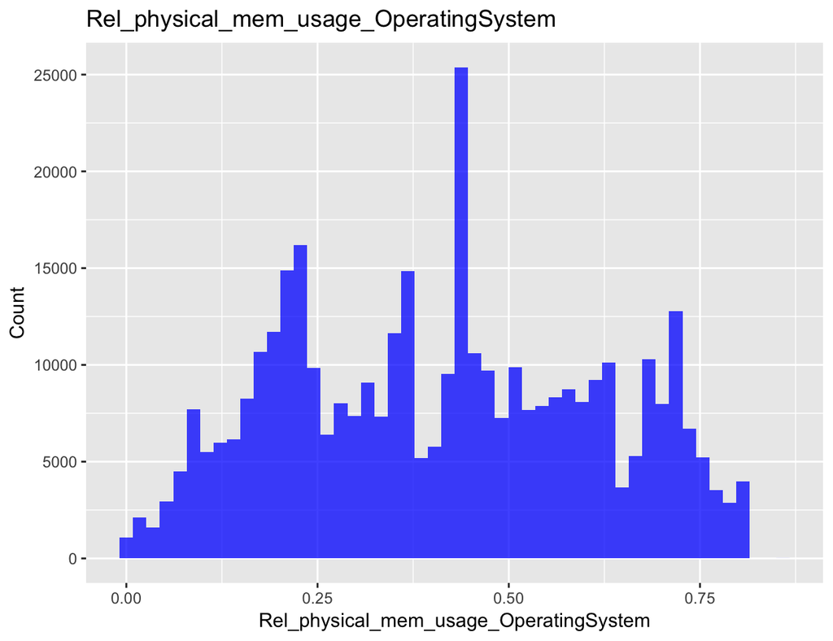

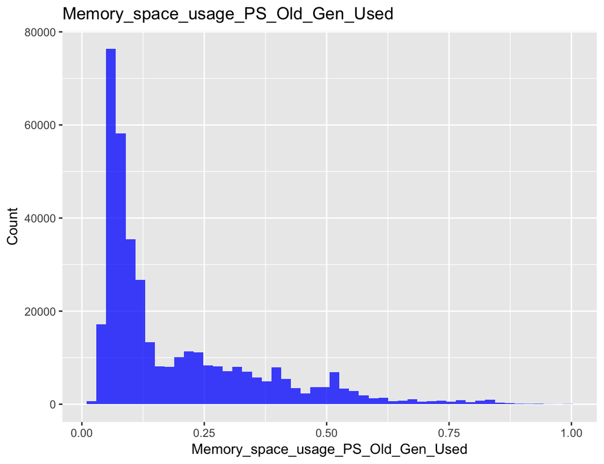

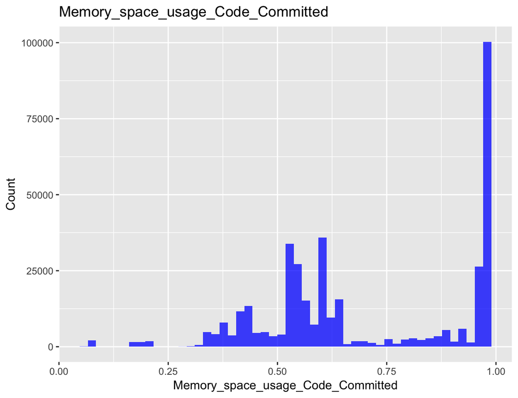

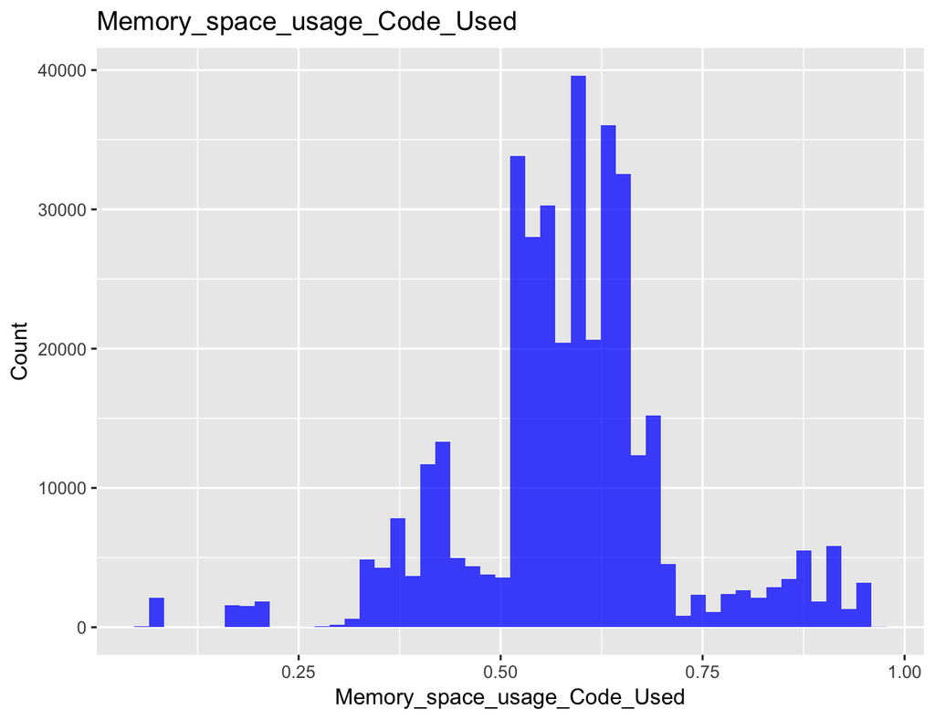

```r
col_agg <-c("Rel_physical_mem_usage_OperatingSystem",
            "Memory_space_usage_PS_Old_Gen_Used",
            "Memory_space_usage_Code_Committed",
            "Memory_space_usage_Code_Used")

for (colum in col_agg) {

  print(plotDistribution(telemetryDF, colum, 50))
}
```

### 2.3.2 Aggregating Columns

For further examination, I made a summarized data.frame grouped by three columns, `host`, `process`, and `Weekday`.

```r
# columns to aggregate on
groupCols <- c("host", "process", "Weekday")
aggCols <- names(telemetryDF2)
aggCols <- aggCols[! aggCols %in% c(groupCols, "timestamp", "isAnomaly",
                                    "No_data", "TS", "Month", "Date", "Hour",
                                    "Minute", "rolling_window", "Biz_Hour", "Weekend", "Biz_Quarter")]

telemetryDF3 <- telemetryDF2 %>%
  group_by_at( groupCols ) %>%
  summarize_at( aggCols, c("min", "mean", "max"), na.rm = TRUE )

nrow(telemetryDF3)
```

```
## [1] 84
```

```r
head(telemetryDF3)
```

```
## # A tibble: 6 x 471
## # Groups:   host, process [1]
##   host  process Weekday Active_connecti~ Active_connecti~ Active_connecti~
##   <chr> <chr>   <fct>              <dbl>            <dbl>            <dbl>
## 1 lpho~ wls2    Friday                 0                0                0
## 2 lpho~ wls2    Monday                 0                0                0
## 3 lpho~ wls2    Saturd~                0                0                0
## 4 lpho~ wls2    Sunday                 0                0                0
## 5 lpho~ wls2    Thursd~                0                0                0
## 6 lpho~ wls2    Tuesday                0                0                0
## # ... with 465 more variables:
## #   Active_connections_source03_JDBCDataSourceRuntime_min <dbl>,
## #   Active_connections_source04_JDBCConnectionPoolRuntime_min <dbl>,
## #   Active_connections_source04_JDBCDataSourceRuntime_min <dbl>,
## #   Active_connections_source05_JDBCConnectionPoolRuntime_min <dbl>,
## #   Active_connections_source05_JDBCDataSourceRuntime_min <dbl>,
## #   Active_connections_source08_JDBCConnectionPoolRuntime_min <dbl>,
## #   Active_connections_source08_JDBCDataSourceRuntime_min <dbl>,
## #   Active_connections_source09_JDBCConnectionPoolRuntime_min <dbl>,
## #   Active_connections_source09_JDBCDataSourceRuntime_min <dbl>,
## #   Active_connections_source10_JDBCConnectionPoolRuntime_min <dbl>,
## #   Active_connections_source10_JDBCDataSourceRuntime_min <dbl>,
## #   Active_transactions_JTARuntime_min <dbl>,
## #   Available_db_connection_activity_source01_JDBCConnectionPoolRuntime_min <dbl>,
## #   Available_db_connection_activity_source01_JDBCDataSourceRuntime_min <dbl>,
## #   Available_db_connection_activity_source02_JDBCConnectionPoolRuntime_min <dbl>,
## #   Available_db_connection_activity_source02_JDBCDataSourceRuntime_min <dbl>,
## #   Available_db_connection_activity_source03_JDBCConnectionPoolRuntime_min <dbl>,
## #   Available_db_connection_activity_source03_JDBCDataSourceRuntime_min <dbl>,
## #   Available_db_connection_activity_source04_JDBCConnectionPoolRuntime_min <dbl>,
## #   Available_db_connection_activity_source04_JDBCDataSourceRuntime_min <dbl>,
## #   Available_db_connection_activity_source05_JDBCConnectionPoolRuntime_min <dbl>,
## #   Available_db_connection_activity_source05_JDBCDataSourceRuntime_min <dbl>,
## #   Available_db_connection_activity_source06_JDBCConnectionPoolRuntime_min <dbl>,
## #   Available_db_connection_activity_source06_JDBCDataSourceRuntime_min <dbl>,
## #   Available_db_connection_activity_source08_JDBCConnectionPoolRuntime_min <dbl>,
## #   Available_db_connection_activity_source08_JDBCDataSourceRuntime_min <dbl>,
## #   Available_db_connection_activity_source09_JDBCConnectionPoolRuntime_min <dbl>,
## #   Available_db_connection_activity_source09_JDBCDataSourceRuntime_min <dbl>,
## #   Available_db_connection_activity_source10_JDBCConnectionPoolRuntime_min <dbl>,
```

[output cut: 52 more lines]

```
## #   Memory_space_activity_PS_Survivor_Space_min <dbl>,
## #   Memory_space_activity_PS_Survivor_Space_Committed_min <dbl>,
## #   Memory_space_commited_div_max_PS_Old_Gen_min <dbl>,
## #   Memory_space_usage_Code_Committed_min <dbl>,
## #   Memory_space_usage_Code_Used_min <dbl>,
## #   Memory_space_usage_PS_Eden_Space_Committed_min <dbl>,
## #   Memory_space_usage_PS_Eden_Space_Used_min <dbl>,
## #   Memory_space_usage_PS_Old_Gen_Committed_min <dbl>,
## #   Memory_space_usage_PS_Old_Gen_Used_min <dbl>,
## #   Memory_space_usage_PS_Perm_Gen_Committed_min <dbl>,
## #   Memory_space_usage_PS_Survivor_Space_Committed_min <dbl>,
## #   Memory_space_usage_PS_Survivor_Space_Used_min <dbl>,
## #   Memory_space_usage_Used_PS_Perm_Gen_Used_min <dbl>,
## #   Memory_space_used_div_max_PS_Old_Gen_min <dbl>,
## #   NonHeap_committed_activity_min <dbl>, ...
```

### 2.3.3 Different Plots by Weekday

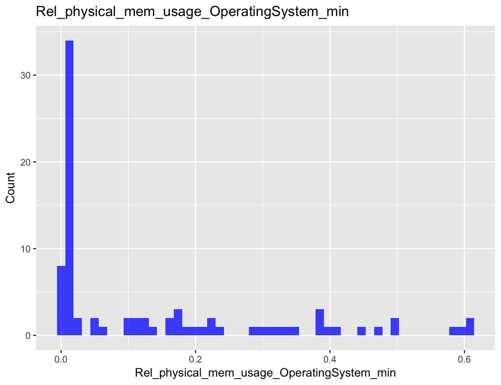

```r
# Function to make a histogram

histFunction <- function(DataFrame=telemetryDF3, col_name, num_bin=10){

  aggCol <-col_name
  sum_col_name = cat(col_name,'_sum',sep='')
  DataFrame %>%
    ungroup %>%
    mutate( sum_col_name = select(., aggCol) %>% rowSums()) %>%
    ggplot(aes(x=sum_col_name))+
    xlab(sum_col_name)+
    geom_histogram(bins=num_bin, fill="skyblue")+
    facet_wrap(~Weekday)+
    labs(title = sum_col_name, x = sum_col_name, y = "Count")

}

# Rel_physical_mem_usage_OperatingSystem_min
plotDistribution(telemetryDF3, "Rel_physical_mem_usage_OperatingSystem_min", 50)
```

```
## Rel_physical_mem_usage_OperatingSystem_min_sum
```

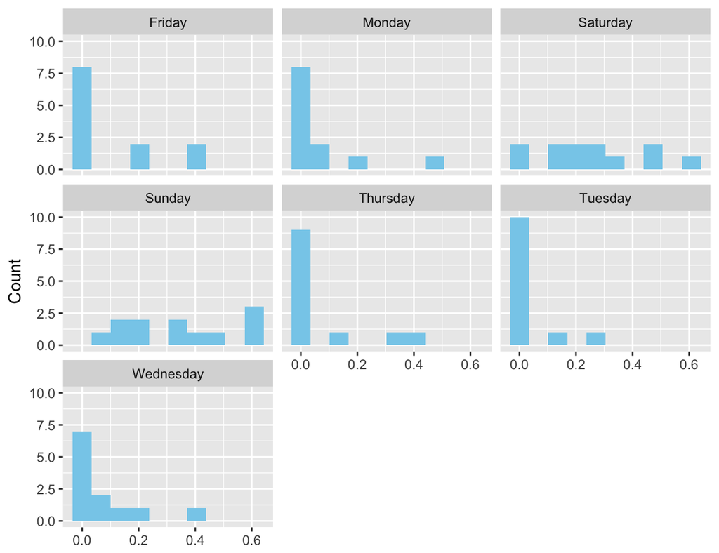

```r
histFunction(col_name = "Rel_physical_mem_usage_OperatingSystem_min")
```

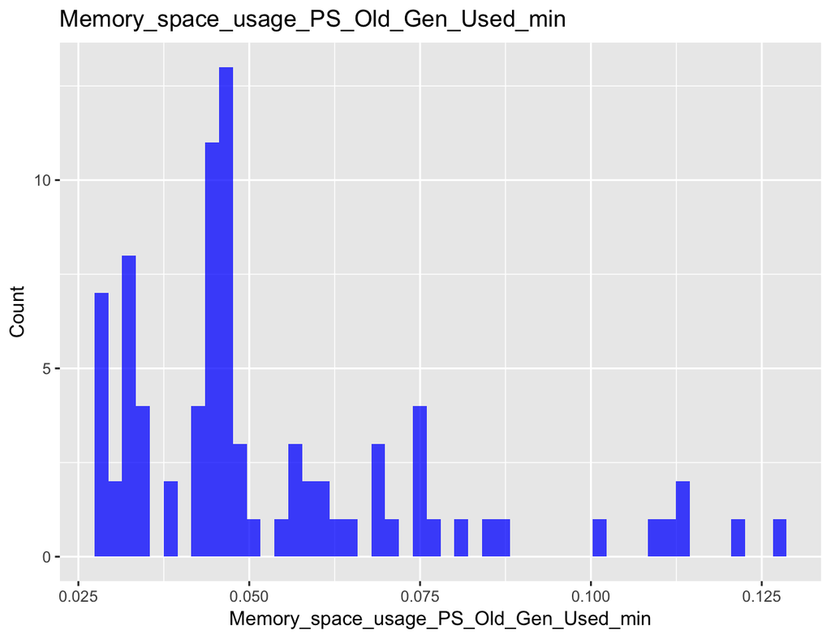

```r
# Memory_space_usage_PS_Old_Gen_Used_min
plotDistribution(telemetryDF3, "Memory_space_usage_PS_Old_Gen_Used_min", 50)
```

```
## Memory_space_usage_PS_Old_Gen_Used_min_sum
```

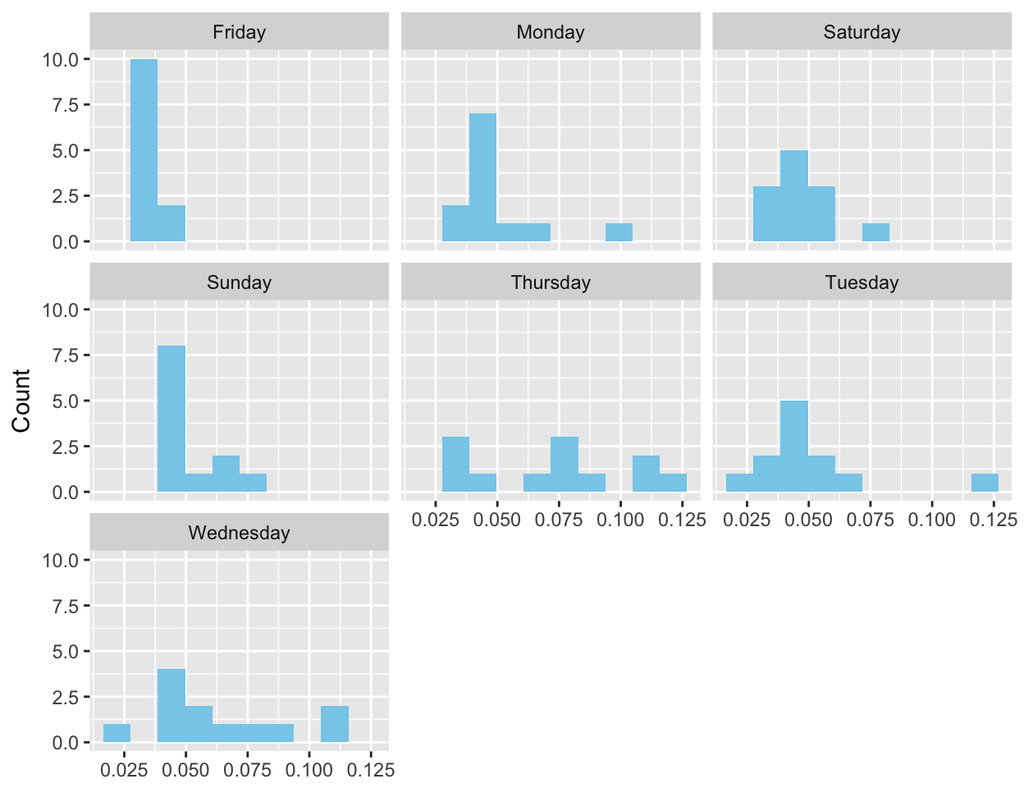

```r
histFunction(col_name = "Memory_space_usage_PS_Old_Gen_Used_min")
```